# Exercise 09

Author

Sarah Lötscher

Published

November 14, 2022

## STA426 Exercise 9: Playing with loess/lowess, adjusting for a batch/technical effect,differential exon usage

```r
#Packages
library(edgeR)
library(ggplot2)
library(vecsets)
library(pasilla)
```

## Question 1.

Simulate data from the sine curve (from 0 to 2*pi) with Gaussian noise added (as shown in the lecture). Try and “normalize” the sine curve data. That is, subtract the estimate of the lowess/loess curve from the simulated data, such that, if your normalization succeeds, you are left with normally distributed data centred around zero. After this: i) make a plot of the normalized data; ii) make a plot of the difference between the truth (sine curve) and the loess/lowess estimate; iii) create a quantile-quantile (against Gaussian) plot of the normalized data. Comment on your result. Does it look (sufficiently) Gaussian? You may need to play with parameters to get a “good” lowess/loess estimate in the first place.

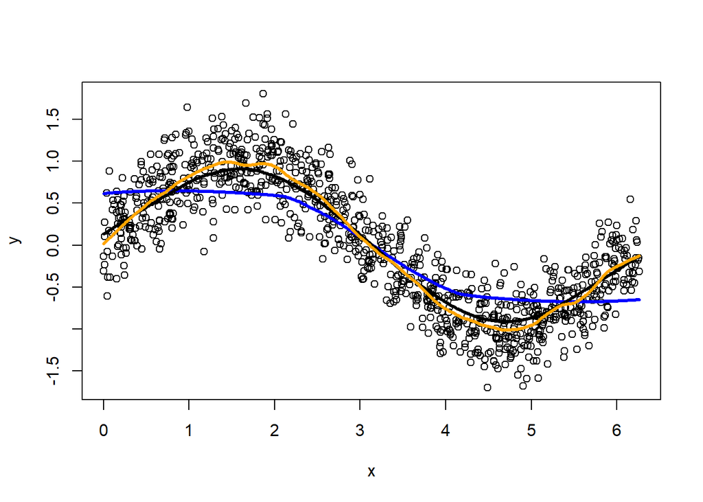

```r
x <- runif(1000, 0, 2*pi)
y <- sin(x) + rnorm(1000, sd = .3)

plot(x,y)
lines(lowess(y~x, f=2/3), col="blue", lwd=3)
lines(lowess(y~x, f=1/3), col="black", lwd=3)
lines(lowess(y~x, f=1/10), col="orange", lwd=3)
```

```r
#“normalize” the sine curve data
df_xy<-data.frame(x,y)
Y_norm <- df_xy[order(df_xy$x),]$y - lowess(x, y, f=1/10)$y
```

1. make a plot of the normalized data

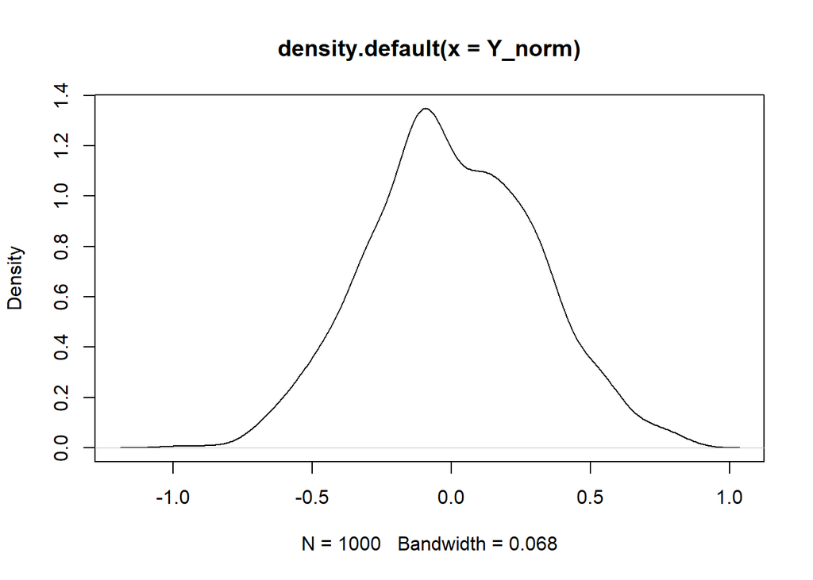

```r
plot(density(Y_norm))
```

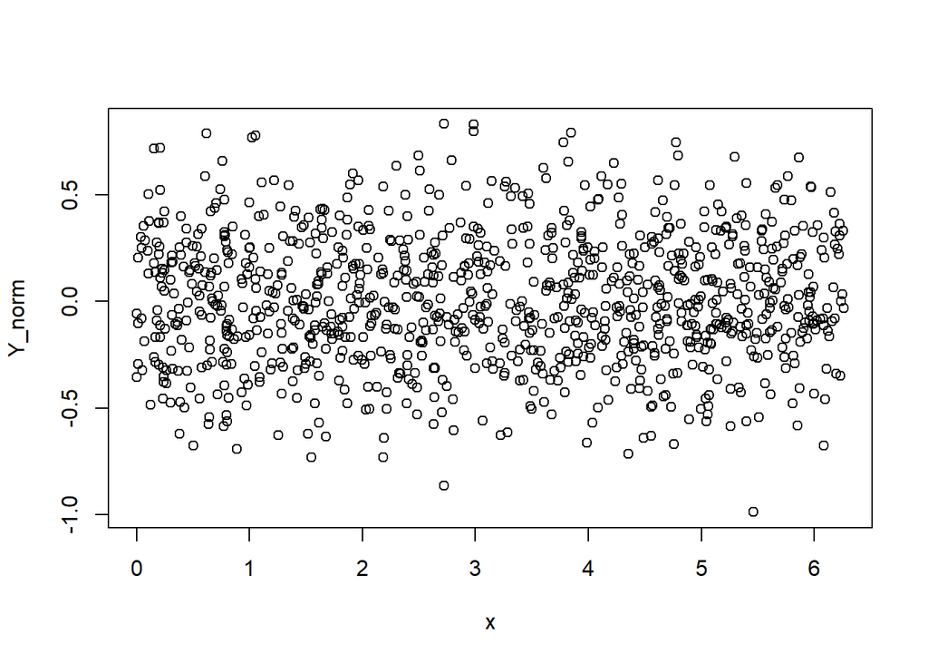

```r
plot(x,Y_norm)
```

2. make a plot of the difference between the truth (sine curve) and the loess/lowess estimate

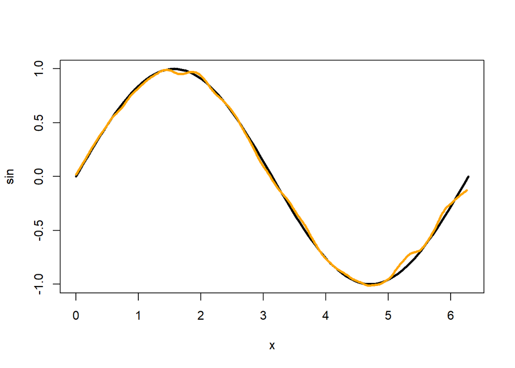

```r
plot(sin,0,2*pi,col="black",lwd=3)
lines(lowess(x, y, f=1/10),col="orange",lwd=3)
```

3. create a quantile-quantile (against Gaussian) plot of the normalized data

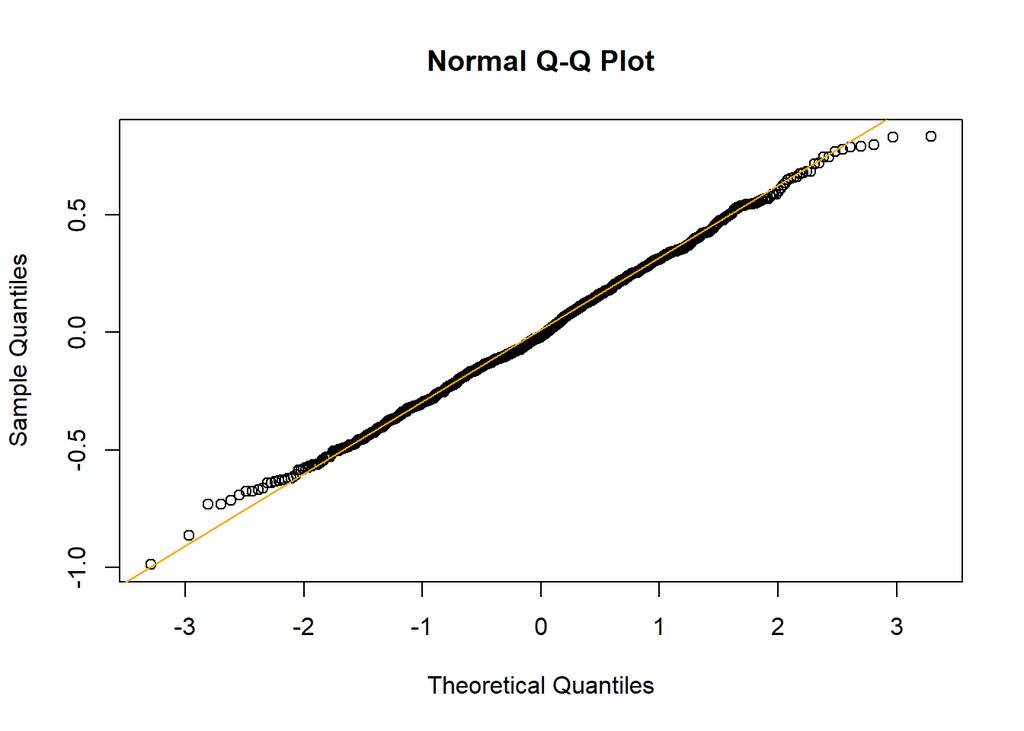

```r
qqnorm(Y_norm)
qqline(Y_norm,col="orange")
```

Looking at the scatter plot of the normalized data the data seems to now be centered around zero. When we look at the density plot there is a nice looking Gaussian curve confirming that the data is nicely centered around zero now. This is also reflected in the qq-plot where the points align nicely along the diagonal. When “normalizing” the sine curve data i needed to order the y values according to x since the lowess function outputs the data ordered.

## Question 2.

Take the data from Exercise 7 and produce an MDS plot again, but this time colour the points according to the covariate in the samples table: libtype (SE = single end, PE = paired end); perhaps also label the points on the MDS plot using the shortname column to make them easy to distinguish. Comment on the relative positions of the samples.

```r
(samples <- read.table("../Exercise7/samples.txt", header=TRUE,
                      row.names=5, stringsAsFactors=FALSE))
```

```
                  rep condition libtype shortname           countfile
CG8144_RNAi-1.bam  T1         T      SE     T1.SE CG8144_RNAi-1.count
CG8144_RNAi-3.bam  T3         T      PE     T3.PE CG8144_RNAi-3.count
CG8144_RNAi-4.bam  T4         T      PE     T4.PE CG8144_RNAi-4.count
Untreated-1.bam    C1         C      SE     C1.SE   Untreated-1.count
Untreated-6.bam    C6         C      SE     C6.SE   Untreated-6.count
Untreated-3.bam    C3         C      PE     C3.PE   Untreated-3.count
Untreated-4.bam    C4         C      PE     C4.PE   Untreated-4.count
```

```r
#From Exercise 7 with added libtype

counts <- readDGE(samples$countfile,path="../Exercise7/")$counts
(grp <- gsub("\\-.[0-9]*","",colnames(counts)))
```

```
[1] "CG8144_RNAi" "CG8144_RNAi" "CG8144_RNAi" "Untreated"   "Untreated"
[6] "Untreated"   "Untreated"
```

```r
(lib <- factor(samples$libtype))
```

```
[1] SE PE PE SE SE PE PE
Levels: PE SE
```

```r
(shortname <-factor(samples$shortname))
```

```
[1] T1.SE T3.PE T4.PE C1.SE C6.SE C3.PE C4.PE
Levels: C1.SE C3.PE C4.PE C6.SE T1.SE T3.PE T4.PE
```

```r
group <-factor(grp)

y <- DGEList(counts=counts,group=grp)
y <- calcNormFactors(y)
design <- model.matrix(~grp)

y <- estimateDisp(y,design)
```

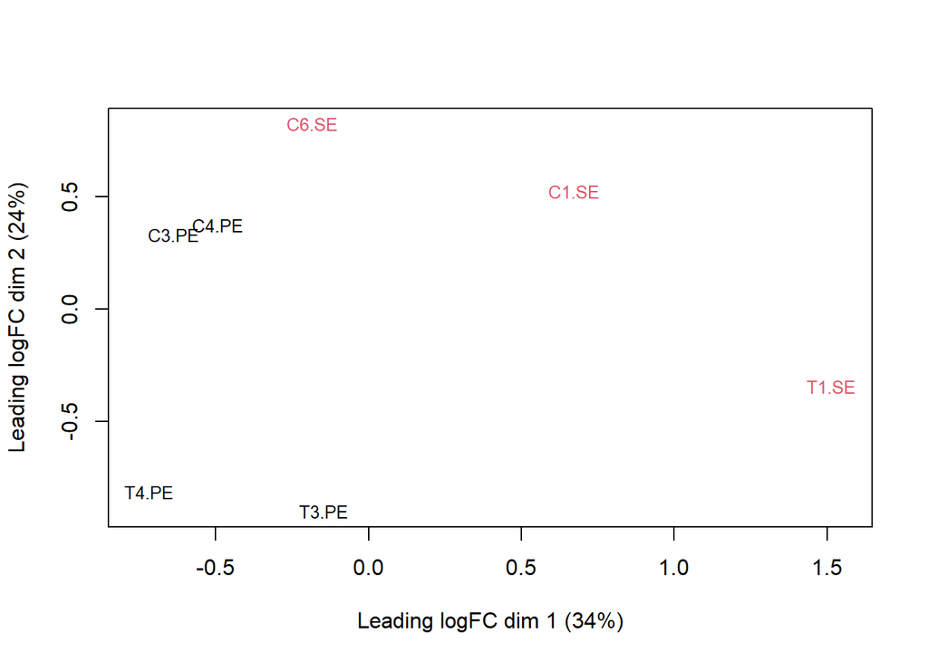

```r
#MDS plot default
mds <- plotMDS( y,col = as.numeric(lib), cex=0.8, labels=samples$shortname)
```

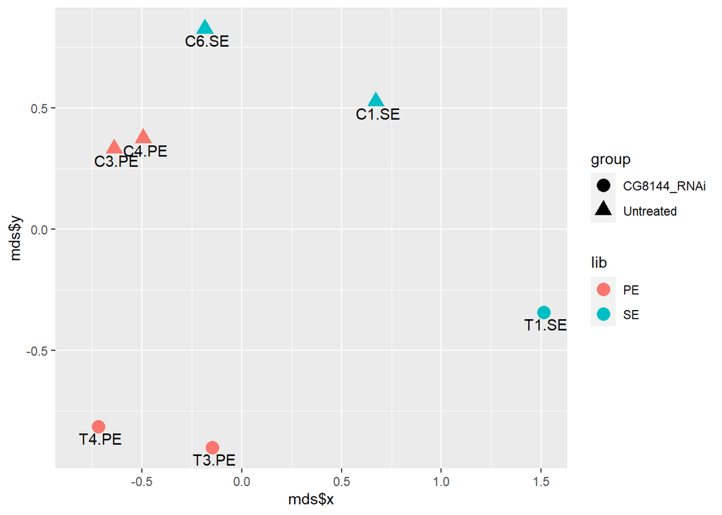

```r
#Even better labeling including the group
qplot(x=mds$x, mds$y) + geom_point(aes(colour=lib, shape=group), size=4)+ geom_text(aes(label=shortname),hjust=0,vjust=1.5,nudge_x=-0.1)
```